# Risk Factor Analysis

## Outcome Variable

**Outcome Variable:** ever_swasted

## Predictor Variables

**Intervention Variable:** birthlen

**Adjustment Set:**

- arm
- sex
- W_mage
- meducyrs
- feducyrs
- vagbrth
- single
- brthmon
- W_parity
- delta_W_mage
- delta_meducyrs
- delta_feducyrs
- delta_vagbrth
- delta_single
- delta_brthmon
- delta_W_parity

## Stratifying Variables

The analysis was stratified on these variable(s):

- agecat
- studyid
- country

## Data Summary

| agecat | studyid | country | birthlen | ever_swasted | n_cell | n |
| --- | --- | --- | --- | --- | --- | --- |
| 0-24 months (no birth wast) | CMC-V-BCS-2002 | INDIA | >=50 cm | 0 | 13 | 104 |
| 0-24 months (no birth wast) | CMC-V-BCS-2002 | INDIA | >=50 cm | 1 | 3 | 104 |
| 0-24 months (no birth wast) | CMC-V-BCS-2002 | INDIA | <48 cm | 0 | 36 | 104 |
| 0-24 months (no birth wast) | CMC-V-BCS-2002 | INDIA | <48 cm | 1 | 12 | 104 |
| 0-24 months (no birth wast) | CMC-V-BCS-2002 | INDIA | [48-50) cm | 0 | 34 | 104 |
| 0-24 months (no birth wast) | CMC-V-BCS-2002 | INDIA | [48-50) cm | 1 | 6 | 104 |
| 0-24 months (no birth wast) | CMIN | BANGLADESH | >=50 cm | 0 | 1 | 17 |
| 0-24 months (no birth wast) | CMIN | BANGLADESH | >=50 cm | 1 | 0 | 17 |
| 0-24 months (no birth wast) | CMIN | BANGLADESH | <48 cm | 0 | 11 | 17 |
| 0-24 months (no birth wast) | CMIN | BANGLADESH | <48 cm | 1 | 0 | 17 |
| 0-24 months (no birth wast) | CMIN | BANGLADESH | [48-50) cm | 0 | 5 | 17 |
| 0-24 months (no birth wast) | CMIN | BANGLADESH | [48-50) cm | 1 | 0 | 17 |
| 0-24 months (no birth wast) | COHORTS | GUATEMALA | >=50 cm | 0 | 418 | 821 |
| 0-24 months (no birth wast) | COHORTS | GUATEMALA | >=50 cm | 1 | 2 | 821 |
| 0-24 months (no birth wast) | COHORTS | GUATEMALA | <48 cm | 0 | 149 | 821 |
| 0-24 months (no birth wast) | COHORTS | GUATEMALA | <48 cm | 1 | 6 | 821 |
| 0-24 months (no birth wast) | COHORTS | GUATEMALA | [48-50) cm | 0 | 243 | 821 |
| 0-24 months (no birth wast) | COHORTS | GUATEMALA | [48-50) cm | 1 | 3 | 821 |
| 0-24 months (no birth wast) | COHORTS | INDIA | >=50 cm | 0 | 1349 | 6400 |
| 0-24 months (no birth wast) | COHORTS | INDIA | >=50 cm | 1 | 40 | 6400 |
| 0-24 months (no birth wast) | COHORTS | INDIA | <48 cm | 0 | 2473 | 6400 |
| 0-24 months (no birth wast) | COHORTS | INDIA | <48 cm | 1 | 171 | 6400 |
| 0-24 months (no birth wast) | COHORTS | INDIA | [48-50) cm | 0 | 2249 | 6400 |
| 0-24 months (no birth wast) | COHORTS | INDIA | [48-50) cm | 1 | 118 | 6400 |
| 0-24 months (no birth wast) | COHORTS | PHILIPPINES | >=50 cm | 0 | 1044 | 3011 |
| 0-24 months (no birth wast) | COHORTS | PHILIPPINES | >=50 cm | 1 | 77 | 3011 |
| 0-24 months (no birth wast) | COHORTS | PHILIPPINES | <48 cm | 0 | 674 | 3011 |
| 0-24 months (no birth wast) | COHORTS | PHILIPPINES | <48 cm | 1 | 66 | 3011 |
| 0-24 months (no birth wast) | COHORTS | PHILIPPINES | [48-50) cm | 0 | 1044 | 3011 |
| 0-24 months (no birth wast) | COHORTS | PHILIPPINES | [48-50) cm | 1 | 106 | 3011 |

[output cut: 126 more lines]

The following strata were considered:

- agecat: 0-24 months (no birth wast), studyid: CMC-V-BCS-2002, country: INDIA
- agecat: 0-24 months (no birth wast), studyid: CMIN, country: BANGLADESH
- agecat: 0-24 months (no birth wast), studyid: COHORTS, country: GUATEMALA
- agecat: 0-24 months (no birth wast), studyid: COHORTS, country: INDIA
- agecat: 0-24 months (no birth wast), studyid: COHORTS, country: PHILIPPINES
- agecat: 0-24 months (no birth wast), studyid: CONTENT, country: PERU
- agecat: 0-24 months (no birth wast), studyid: EE, country: PAKISTAN
- agecat: 0-24 months (no birth wast), studyid: GMS-Nepal, country: NEPAL
- agecat: 0-24 months (no birth wast), studyid: IRC, country: INDIA
- agecat: 0-24 months (no birth wast), studyid: JiVitA-3, country: BANGLADESH
- agecat: 0-24 months (no birth wast), studyid: JiVitA-4, country: BANGLADESH
- agecat: 0-24 months (no birth wast), studyid: Keneba, country: GAMBIA
- agecat: 0-24 months (no birth wast), studyid: MAL-ED, country: BANGLADESH
- agecat: 0-24 months (no birth wast), studyid: MAL-ED, country: BRAZIL
- agecat: 0-24 months (no birth wast), studyid: MAL-ED, country: INDIA
- agecat: 0-24 months (no birth wast), studyid: MAL-ED, country: NEPAL
- agecat: 0-24 months (no birth wast), studyid: MAL-ED, country: PERU
- agecat: 0-24 months (no birth wast), studyid: MAL-ED, country: SOUTH AFRICA
- agecat: 0-24 months (no birth wast), studyid: MAL-ED, country: TANZANIA, UNITED REPUBLIC OF
- agecat: 0-24 months (no birth wast), studyid: NIH-Birth, country: BANGLADESH
- agecat: 0-24 months (no birth wast), studyid: NIH-Crypto, country: BANGLADESH
- agecat: 0-24 months (no birth wast), studyid: PROBIT, country: BELARUS
- agecat: 0-24 months (no birth wast), studyid: PROVIDE, country: BANGLADESH
- agecat: 0-24 months (no birth wast), studyid: ResPak, country: PAKISTAN
- agecat: 0-24 months (no birth wast), studyid: SAS-CompFeed, country: INDIA
- agecat: 0-24 months (no birth wast), studyid: ZVITAMBO, country: ZIMBABWE

### Dropped Strata

Some strata were dropped due to rare outcomes:

- agecat: 0-24 months (no birth wast), studyid: CMC-V-BCS-2002, country: INDIA
- agecat: 0-24 months (no birth wast), studyid: CMIN, country: BANGLADESH
- agecat: 0-24 months (no birth wast), studyid: COHORTS, country: GUATEMALA
- agecat: 0-24 months (no birth wast), studyid: CONTENT, country: PERU
- agecat: 0-24 months (no birth wast), studyid: EE, country: PAKISTAN
- agecat: 0-24 months (no birth wast), studyid: MAL-ED, country: BANGLADESH
- agecat: 0-24 months (no birth wast), studyid: MAL-ED, country: BRAZIL
- agecat: 0-24 months (no birth wast), studyid: MAL-ED, country: INDIA
- agecat: 0-24 months (no birth wast), studyid: MAL-ED, country: NEPAL
- agecat: 0-24 months (no birth wast), studyid: MAL-ED, country: PERU
- agecat: 0-24 months (no birth wast), studyid: MAL-ED, country: SOUTH AFRICA
- agecat: 0-24 months (no birth wast), studyid: MAL-ED, country: TANZANIA, UNITED REPUBLIC OF
- agecat: 0-24 months (no birth wast), studyid: NIH-Crypto, country: BANGLADESH
- agecat: 0-24 months (no birth wast), studyid: PROBIT, country: BELARUS
- agecat: 0-24 months (no birth wast), studyid: PROVIDE, country: BANGLADESH
- agecat: 0-24 months (no birth wast), studyid: ResPak, country: PAKISTAN

## Methods Detail

We're interested in the causal parameters $E[Y_a]$ for all values of $a \in \mathcal{A}$. These parameters represent the mean outcome if, possibly contrary to fact, we intervened to set all units to have $A=a$. Under the randomization and positivity assumptions, these are identified by the statistical parameters $\psi_a=E_W[E_{Y|A,W}(Y|A=a,W)]$. In addition, we're interested in the mean of $Y$, $E[Y]$ under no intervention (the observed mean). We will estimate these parameters by using SuperLearner to fit the relevant likelihood factors -- $E_{Y|A,W}(Y|A=a,W)$ and $p(A=a|W)$, and then updating our likelihood fit using a joint TMLE.

For unadjusted analyses ($W=\{\}$), initial likelihoods were estimated using Lrnr_glm to estimate the simple $E(Y|A)$ and Lrnr_mean to estimate $p(A)$. For adjusted analyses, a small library containing Lrnr_glmnet, Lrnr_xgboost, and Lrnr_mean was used.

Having estimated these parameters, we will then use the delta method to estimate relative risks and attributable risks relative to a prespecified baseline level of $A$.

# Results Detail

## Results Plots

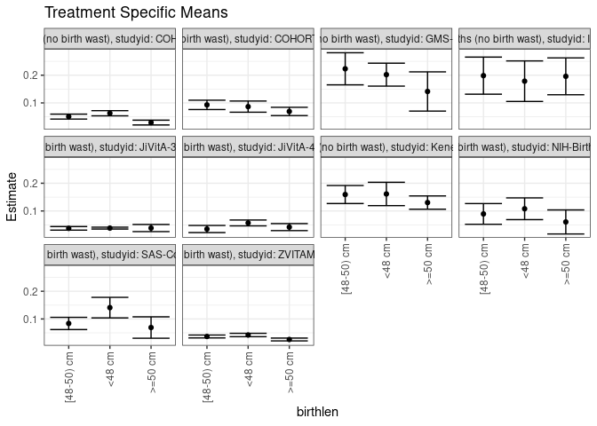

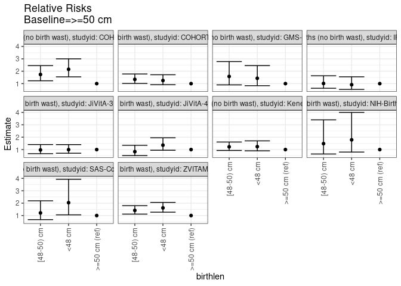

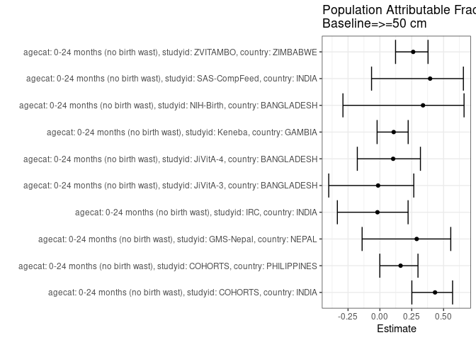

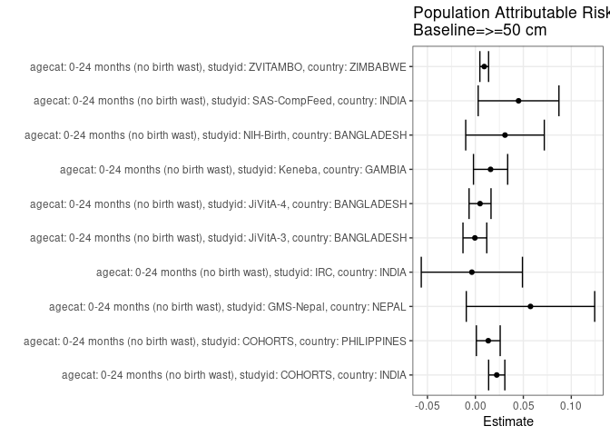

## Results Table

### Parameter: TSM

| agecat | studyid | country | intervention_level | baseline_level | estimate | ci_lower | ci_upper |
| --- | --- | --- | --- | --- | --- | --- | --- |
| 0-24 months (no birth wast) | COHORTS | INDIA | >=50 cm | NA | 0.0291513 | 0.0204812 | 0.0378214 |
| 0-24 months (no birth wast) | COHORTS | INDIA | <48 cm | NA | 0.0628048 | 0.0535263 | 0.0720833 |
| 0-24 months (no birth wast) | COHORTS | INDIA | [48-50) cm | NA | 0.0506378 | 0.0416853 | 0.0595904 |
| 0-24 months (no birth wast) | COHORTS | PHILIPPINES | >=50 cm | NA | 0.0692573 | 0.0543620 | 0.0841526 |
| 0-24 months (no birth wast) | COHORTS | PHILIPPINES | <48 cm | NA | 0.0866632 | 0.0664893 | 0.1068372 |
| 0-24 months (no birth wast) | COHORTS | PHILIPPINES | [48-50) cm | NA | 0.0929504 | 0.0761120 | 0.1097888 |
| 0-24 months (no birth wast) | GMS-Nepal | NEPAL | >=50 cm | NA | 0.1413322 | 0.0705371 | 0.2121274 |
| 0-24 months (no birth wast) | GMS-Nepal | NEPAL | <48 cm | NA | 0.2020320 | 0.1607099 | 0.2433542 |
| 0-24 months (no birth wast) | GMS-Nepal | NEPAL | [48-50) cm | NA | 0.2231565 | 0.1652546 | 0.2810585 |
| 0-24 months (no birth wast) | IRC | INDIA | >=50 cm | NA | 0.1959854 | 0.1295198 | 0.2624510 |
| 0-24 months (no birth wast) | IRC | INDIA | <48 cm | NA | 0.1784596 | 0.1053546 | 0.2515645 |
| 0-24 months (no birth wast) | IRC | INDIA | [48-50) cm | NA | 0.1984188 | 0.1315281 | 0.2653095 |
| 0-24 months (no birth wast) | JiVitA-3 | BANGLADESH | >=50 cm | NA | 0.0383395 | 0.0254564 | 0.0512226 |
| 0-24 months (no birth wast) | JiVitA-3 | BANGLADESH | <48 cm | NA | 0.0380970 | 0.0347751 | 0.0414188 |
| 0-24 months (no birth wast) | JiVitA-3 | BANGLADESH | [48-50) cm | NA | 0.0372289 | 0.0307445 | 0.0437133 |
| 0-24 months (no birth wast) | JiVitA-4 | BANGLADESH | >=50 cm | NA | 0.0417392 | 0.0290589 | 0.0544196 |
| 0-24 months (no birth wast) | JiVitA-4 | BANGLADESH | <48 cm | NA | 0.0567580 | 0.0461460 | 0.0673701 |
| 0-24 months (no birth wast) | JiVitA-4 | BANGLADESH | [48-50) cm | NA | 0.0347900 | 0.0219681 | 0.0476119 |
| 0-24 months (no birth wast) | Keneba | GAMBIA | >=50 cm | NA | 0.1302614 | 0.1062914 | 0.1542314 |
| 0-24 months (no birth wast) | Keneba | GAMBIA | <48 cm | NA | 0.1613031 | 0.1191965 | 0.2034097 |
| 0-24 months (no birth wast) | Keneba | GAMBIA | [48-50) cm | NA | 0.1592791 | 0.1267657 | 0.1917924 |
| 0-24 months (no birth wast) | NIH-Birth | BANGLADESH | >=50 cm | NA | 0.0603448 | 0.0169740 | 0.1037156 |
| 0-24 months (no birth wast) | NIH-Birth | BANGLADESH | <48 cm | NA | 0.1078838 | 0.0686823 | 0.1470853 |
| 0-24 months (no birth wast) | NIH-Birth | BANGLADESH | [48-50) cm | NA | 0.0892857 | 0.0519108 | 0.1266606 |
| 0-24 months (no birth wast) | SAS-CompFeed | INDIA | >=50 cm | NA | 0.0691592 | 0.0305706 | 0.1077478 |
| 0-24 months (no birth wast) | SAS-CompFeed | INDIA | <48 cm | NA | 0.1409706 | 0.1039073 | 0.1780338 |
| 0-24 months (no birth wast) | SAS-CompFeed | INDIA | [48-50) cm | NA | 0.0838432 | 0.0618113 | 0.1058751 |
| 0-24 months (no birth wast) | ZVITAMBO | ZIMBABWE | >=50 cm | NA | 0.0260407 | 0.0210028 | 0.0310786 |
| 0-24 months (no birth wast) | ZVITAMBO | ZIMBABWE | <48 cm | NA | 0.0421587 | 0.0360690 | 0.0482483 |
| 0-24 months (no birth wast) | ZVITAMBO | ZIMBABWE | [48-50) cm | NA | 0.0368692 | 0.0316934 | 0.0420451 |

### Parameter: E(Y)

| agecat | studyid | country | intervention_level | baseline_level | estimate | ci_lower | ci_upper |
| --- | --- | --- | --- | --- | --- | --- | --- |
| 0-24 months (no birth wast) | COHORTS | INDIA | NA | NA | 0.0514063 | 0.0459957 | 0.0568168 |
| 0-24 months (no birth wast) | COHORTS | PHILIPPINES | NA | NA | 0.0826968 | 0.0728574 | 0.0925361 |
| 0-24 months (no birth wast) | GMS-Nepal | NEPAL | NA | NA | 0.1987860 | 0.1682929 | 0.2292792 |
| 0-24 months (no birth wast) | IRC | INDIA | NA | NA | 0.1923077 | 0.1531430 | 0.2314724 |
| 0-24 months (no birth wast) | JiVitA-3 | BANGLADESH | NA | NA | 0.0377996 | 0.0348944 | 0.0407048 |
| 0-24 months (no birth wast) | JiVitA-4 | BANGLADESH | NA | NA | 0.0465950 | 0.0398949 | 0.0532951 |
| 0-24 months (no birth wast) | Keneba | GAMBIA | NA | NA | 0.1460892 | 0.1284833 | 0.1636951 |
| 0-24 months (no birth wast) | NIH-Birth | BANGLADESH | NA | NA | 0.0912220 | 0.0677898 | 0.1146542 |
| 0-24 months (no birth wast) | SAS-CompFeed | INDIA | NA | NA | 0.1141706 | 0.0903032 | 0.1380379 |
| 0-24 months (no birth wast) | ZVITAMBO | ZIMBABWE | NA | NA | 0.0352566 | 0.0321456 | 0.0383677 |

### Parameter: RR

| agecat | studyid | country | intervention_level | baseline_level | estimate | ci_lower | ci_upper |
| --- | --- | --- | --- | --- | --- | --- | --- |
| 0-24 months (no birth wast) | COHORTS | INDIA | >=50 cm | >=50 cm | 1.0000000 | 1.0000000 | 1.000000 |
| 0-24 months (no birth wast) | COHORTS | INDIA | <48 cm | >=50 cm | 2.1544419 | 1.5458537 | 3.002626 |
| 0-24 months (no birth wast) | COHORTS | INDIA | [48-50) cm | >=50 cm | 1.7370694 | 1.2292632 | 2.454649 |
| 0-24 months (no birth wast) | COHORTS | PHILIPPINES | >=50 cm | >=50 cm | 1.0000000 | 1.0000000 | 1.000000 |
| 0-24 months (no birth wast) | COHORTS | PHILIPPINES | <48 cm | >=50 cm | 1.2513231 | 0.9120104 | 1.716877 |
| 0-24 months (no birth wast) | COHORTS | PHILIPPINES | [48-50) cm | >=50 cm | 1.3421030 | 1.0136033 | 1.777067 |
| 0-24 months (no birth wast) | GMS-Nepal | NEPAL | >=50 cm | >=50 cm | 1.0000000 | 1.0000000 | 1.000000 |
| 0-24 months (no birth wast) | GMS-Nepal | NEPAL | <48 cm | >=50 cm | 1.4294831 | 0.8322654 | 2.455253 |
| 0-24 months (no birth wast) | GMS-Nepal | NEPAL | [48-50) cm | >=50 cm | 1.5789500 | 0.8979508 | 2.776414 |
| 0-24 months (no birth wast) | IRC | INDIA | >=50 cm | >=50 cm | 1.0000000 | 1.0000000 | 1.000000 |
| 0-24 months (no birth wast) | IRC | INDIA | <48 cm | >=50 cm | 0.9105758 | 0.5347107 | 1.550648 |
| 0-24 months (no birth wast) | IRC | INDIA | [48-50) cm | >=50 cm | 1.0124164 | 0.6276294 | 1.633109 |
| 0-24 months (no birth wast) | JiVitA-3 | BANGLADESH | >=50 cm | >=50 cm | 1.0000000 | 1.0000000 | 1.000000 |
| 0-24 months (no birth wast) | JiVitA-3 | BANGLADESH | <48 cm | >=50 cm | 0.9936739 | 0.7053539 | 1.399847 |
| 0-24 months (no birth wast) | JiVitA-3 | BANGLADESH | [48-50) cm | >=50 cm | 0.9710331 | 0.6709644 | 1.405299 |
| 0-24 months (no birth wast) | JiVitA-4 | BANGLADESH | >=50 cm | >=50 cm | 1.0000000 | 1.0000000 | 1.000000 |
| 0-24 months (no birth wast) | JiVitA-4 | BANGLADESH | <48 cm | >=50 cm | 1.3598243 | 0.9479802 | 1.950592 |
| 0-24 months (no birth wast) | JiVitA-4 | BANGLADESH | [48-50) cm | >=50 cm | 0.8335081 | 0.5159485 | 1.346521 |
| 0-24 months (no birth wast) | Keneba | GAMBIA | >=50 cm | >=50 cm | 1.0000000 | 1.0000000 | 1.000000 |
| 0-24 months (no birth wast) | Keneba | GAMBIA | <48 cm | >=50 cm | 1.2383032 | 0.9004199 | 1.702978 |
| 0-24 months (no birth wast) | Keneba | GAMBIA | [48-50) cm | >=50 cm | 1.2227649 | 0.9288590 | 1.609667 |
| 0-24 months (no birth wast) | NIH-Birth | BANGLADESH | >=50 cm | >=50 cm | 1.0000000 | 1.0000000 | 1.000000 |
| 0-24 months (no birth wast) | NIH-Birth | BANGLADESH | <48 cm | >=50 cm | 1.7877890 | 0.7990190 | 4.000142 |
| 0-24 months (no birth wast) | NIH-Birth | BANGLADESH | [48-50) cm | >=50 cm | 1.4795918 | 0.6440585 | 3.399058 |
| 0-24 months (no birth wast) | SAS-CompFeed | INDIA | >=50 cm | >=50 cm | 1.0000000 | 1.0000000 | 1.000000 |
| 0-24 months (no birth wast) | SAS-CompFeed | INDIA | <48 cm | >=50 cm | 2.0383487 | 1.0577109 | 3.928167 |
| 0-24 months (no birth wast) | SAS-CompFeed | INDIA | [48-50) cm | >=50 cm | 1.2123216 | 0.6711113 | 2.189985 |
| 0-24 months (no birth wast) | ZVITAMBO | ZIMBABWE | >=50 cm | >=50 cm | 1.0000000 | 1.0000000 | 1.000000 |
| 0-24 months (no birth wast) | ZVITAMBO | ZIMBABWE | <48 cm | >=50 cm | 1.6189530 | 1.2716360 | 2.061131 |
| 0-24 months (no birth wast) | ZVITAMBO | ZIMBABWE | [48-50) cm | >=50 cm | 1.4158309 | 1.1147979 | 1.798153 |

### Parameter: PAR

| agecat | studyid | country | intervention_level | baseline_level | estimate | ci_lower | ci_upper |
| --- | --- | --- | --- | --- | --- | --- | --- |
| 0-24 months (no birth wast) | COHORTS | INDIA | >=50 cm | NA | 0.0222550 | 0.0138082 | 0.0307017 |
| 0-24 months (no birth wast) | COHORTS | PHILIPPINES | >=50 cm | NA | 0.0134395 | 0.0010239 | 0.0258551 |
| 0-24 months (no birth wast) | GMS-Nepal | NEPAL | >=50 cm | NA | 0.0574538 | -0.0095030 | 0.1244106 |
| 0-24 months (no birth wast) | IRC | INDIA | >=50 cm | NA | -0.0036777 | -0.0564425 | 0.0490870 |
| 0-24 months (no birth wast) | JiVitA-3 | BANGLADESH | >=50 cm | NA | -0.0005399 | -0.0129442 | 0.0118643 |
| 0-24 months (no birth wast) | JiVitA-4 | BANGLADESH | >=50 cm | NA | 0.0048557 | -0.0065946 | 0.0163061 |
| 0-24 months (no birth wast) | Keneba | GAMBIA | >=50 cm | NA | 0.0158278 | -0.0019946 | 0.0336502 |
| 0-24 months (no birth wast) | NIH-Birth | BANGLADESH | >=50 cm | NA | 0.0308772 | -0.0100981 | 0.0718525 |
| 0-24 months (no birth wast) | SAS-CompFeed | INDIA | >=50 cm | NA | 0.0450114 | 0.0029031 | 0.0871197 |
| 0-24 months (no birth wast) | ZVITAMBO | ZIMBABWE | >=50 cm | NA | 0.0092160 | 0.0046717 | 0.0137602 |

### Parameter: PAF

| agecat | studyid | country | intervention_level | baseline_level | estimate | ci_lower | ci_upper |
| --- | --- | --- | --- | --- | --- | --- | --- |
| 0-24 months (no birth wast) | COHORTS | INDIA | >=50 cm | NA | 0.4329231 | 0.2509607 | 0.5706818 |
| 0-24 months (no birth wast) | COHORTS | PHILIPPINES | >=50 cm | NA | 0.1625154 | -0.0006491 | 0.2990745 |
| 0-24 months (no birth wast) | GMS-Nepal | NEPAL | >=50 cm | NA | 0.2890234 | -0.1395272 | 0.5564057 |
| 0-24 months (no birth wast) | IRC | INDIA | >=50 cm | NA | -0.0191241 | -0.3338993 | 0.2213700 |
| 0-24 months (no birth wast) | JiVitA-3 | BANGLADESH | >=50 cm | NA | -0.0142836 | -0.4016726 | 0.2660403 |
| 0-24 months (no birth wast) | JiVitA-4 | BANGLADESH | >=50 cm | NA | 0.1042116 | -0.1771889 | 0.3183449 |
| 0-24 months (no birth wast) | Keneba | GAMBIA | >=50 cm | NA | 0.1083434 | -0.0219284 | 0.2220087 |
| 0-24 months (no birth wast) | NIH-Birth | BANGLADESH | >=50 cm | NA | 0.3384841 | -0.2900440 | 0.6607842 |
| 0-24 months (no birth wast) | SAS-CompFeed | INDIA | >=50 cm | NA | 0.3942467 | -0.0654438 | 0.6556017 |
| 0-24 months (no birth wast) | ZVITAMBO | ZIMBABWE | >=50 cm | NA | 0.2613963 | 0.1229399 | 0.3779954 |